# CMJ_Framework_Documentation

```python
# =========================================================
# CMJ Framework – Notebook Initialization
# =========================================================

import os
import sys
from pathlib import Path
import json

import pandas as pd
import numpy as np
import matplotlib.pyplot as plt

PROJECT_ROOT = Path.cwd().parent if Path.cwd().name.lower() == "documentation" else Path.cwd()

if str(PROJECT_ROOT) not in sys.path:
    sys.path.insert(0, str(PROJECT_ROOT))

print("Project root:", PROJECT_ROOT)
```

```
Project root: c:\Users\johan\Downloads\projekt_rdvkb-20260216T204542Z-1-001\projekt_rdvkb\cmj_framework
```

```python
# %%
# =========================================================
# Import CMJ framework modules
# =========================================================

from src.cmj_framework.utils.signal_processing import SignalProcessing
from src.cmj_framework.utils.roi import CMJ_ROI
from src.cmj_framework.utils.metrics import JumpMetrics
from src.cmj_framework.utils.visualisation import CMJPlot
from src.cmj_framework.utils.pathmanager import PathManager
from src.cmj_framework.data_processing.run_processing_temp_data import TempProcessedData

print("CMJ framework modules imported successfully")
```

```
CMJ framework modules imported successfully
```

# CMJ Framework – Dokumentation

Software zur Analyse von Countermovement Jumps (CMJ) auf Basis vertikaler Bodenreaktionskräfte, Markertrajektorien und automatisierter biomechanischer Auswertung.

Diese Dokumentation beschreibt die aktuelle Architektur, den Analyse-Workflow, die Konfigurationsstruktur, die grafische Benutzeroberfläche sowie die berechneten biomechanischen Parameter des CMJ-Frameworks.

**Institution:** Marienstift Arnstadt – Fachklinik für Orthopädie

## Inhaltsverzeichnis

1. Einführung
2. Systemübersicht
3. Softwarearchitektur
4. Konfigurationssystem
5. Analysepipeline
6. Biomechanische Grundlagen
7. Dynamische Gleichungen
8. Beispieldatensatz
9. Signalextraktion und Vorverarbeitung
10. ROI-Erkennung
11. Wissenschaftliche Force-Time-Darstellung
12. Berechnung der Metriken
13. Analyse mehrerer Trials
14. Schematische CMJ-Darstellung
15. Architekturdiagramm des Frameworks
16. Grafische Benutzeroberfläche
17. Berichtserstellung
18. Methodische Hinweise
19. Literatur

```python
# %%
# =========================================================
# Example patient data
# =========================================================

PATIENT_FOLDER = Path(PathManager.canonical_base_dir()) / "Max, Mustermann" / "01.01.2020"
RAW_FOLDER = PATIENT_FOLDER / "raw_data"

print("Patient folder:", PATIENT_FOLDER)
print("Raw data folder:", RAW_FOLDER)

raw_files = sorted(RAW_FOLDER.glob("*_data_cmj.json"))

print("Number of trials:", len(raw_files))
raw_files
```

```
Patient folder: C:\Users\johan\Documents\CMJ_manager\Max, Mustermann\01.01.2020
Raw data folder: C:\Users\johan\Documents\CMJ_manager\Max, Mustermann\01.01.2020\raw_data
Number of trials: 9
```

```
[WindowsPath('C:/Users/johan/Documents/CMJ_manager/Max, Mustermann/01.01.2020/raw_data/1234_10102020_01_data_cmj.json'),
 WindowsPath('C:/Users/johan/Documents/CMJ_manager/Max, Mustermann/01.01.2020/raw_data/1234_10102020_02_data_cmj.json'),
 WindowsPath('C:/Users/johan/Documents/CMJ_manager/Max, Mustermann/01.01.2020/raw_data/1234_10102020_03_data_cmj.json'),
 WindowsPath('C:/Users/johan/Documents/CMJ_manager/Max, Mustermann/01.01.2020/raw_data/1234_10102020_04_data_cmj.json'),
 WindowsPath('C:/Users/johan/Documents/CMJ_manager/Max, Mustermann/01.01.2020/raw_data/1234_10102020_05_data_cmj.json'),
 WindowsPath('C:/Users/johan/Documents/CMJ_manager/Max, Mustermann/01.01.2020/raw_data/1234_10102020_06_data_cmj.json'),
 WindowsPath('C:/Users/johan/Documents/CMJ_manager/Max, Mustermann/01.01.2020/raw_data/1234_10102020_07_data_cmj.json'),
 WindowsPath('C:/Users/johan/Documents/CMJ_manager/Max, Mustermann/01.01.2020/raw_data/1234_10102020_08_data_cmj.json'),
 WindowsPath('C:/Users/johan/Documents/CMJ_manager/Max, Mustermann/01.01.2020/raw_data/1234_10102020_09_data_cmj.json')]
```

## 1. Einführung

Der Countermovement Jump (CMJ) ist ein etablierter Test zur Beurteilung der neuromuskulären Leistungsfähigkeit der unteren Extremitäten. Die Analyse der vertikalen Bodenreaktionskräfte erlaubt eine quantitative Beschreibung des Sprungverhaltens und liefert klinisch relevante Kennwerte für Kraftentwicklung, Leistung, Phasenstruktur und Seitenasymmetrie.

Das CMJ-Framework wurde entwickelt, um diese Auswertung standardisiert, reproduzierbar und visuell überprüfbar durchzuführen. Neben der reinen Signalverarbeitung integriert das System auch eine grafische Benutzeroberfläche, eine konfigurierbare Datenpipeline sowie einen automatisierten Word-Bericht.

Typische berechnete Parameter sind unter anderem:

- Sprunghöhe
- Maximalkraft
- Rate of Force Development
- Absprungsgeschwindigkeit
- konzentrische Leistung
- Landungskennwerte
- Links-Rechts-Asymmetrien

⬆ Zurück zum Inhaltsverzeichnis

## 2. Systemübersicht

Das CMJ-Framework besteht aus mehreren funktionell getrennten, aber eng zusammenarbeitenden Modulen:

- Extraktion der Rohdaten aus **Vicon Nexus**
- Umwandlung in ein internes **JSON-Format**
- Verarbeitung der Kraft- und Markertrajektorien
- automatische ROI-Erkennung und Phasenanalyse
- Berechnung biomechanischer Kennwerte
- Visualisierung und manuelle Trial-Beurteilung
- Erstellung eines standardisierten Word-Berichts

Die Software ist modular aufgebaut und so konzipiert, dass Rohdaten, Zwischenergebnisse und finale Berichte innerhalb einer einheitlichen patienten- und sitzungsbezogenen Ordnerstruktur verwaltet werden.

⬆ Zurück zum Inhaltsverzeichnis

## 3. Softwarearchitektur

Die aktuelle Softwarearchitektur ist in mehrere Hauptpakete gegliedert:

- **gui**  
  Grafische Benutzeroberfläche, Navigation, Folder Explorer, Trial-Visualisierung, Parameteransicht und Exportsteuerung
- **data_processing**  
  Verarbeitung extrahierter JSON-Dateien, Berechnung biomechanischer Kennwerte, temporäre Trial-Verwaltung und Fehlerbehandlung
- **export**  
  Erstellung standardisierter Word-Berichte aus kombinierten Ergebnisdateien (`*_combined.json`)
- **utils**  
  Wissenschaftliche Kernfunktionen wie Signalverarbeitung, ROI-Erkennung, Metrikberechnung, Validierung, Pfadmanagement und Plotting
- **vicon_data_retrieval**  
  Extraktion von Rohdaten aus Vicon Nexus sowie Export in das interne JSON-Format

Zusätzlich verwendet das Projekt zentrale Projektordner für:

- **config**  
  JSON-basierte Konfigurationsdateien für Analyse, Vicon-Extraktion, Utilities und Berichtserstellung
- **documentation**  
  Technische Dokumentation des Frameworks, Notebook und HTML-Export

Die modulare Struktur erleichtert Wartung, Erweiterbarkeit und klinische Nachvollziehbarkeit.

⬆ Zurück zum Inhaltsverzeichnis

## 4. Konfigurationssystem

Das aktuelle CMJ-Framework verwendet ein zentrales Konfigurationssystem auf Basis von JSON-Dateien. Analyseverhalten, Exportparameter, Vicon-Extraktion und verschiedene wissenschaftliche Schwellenwerte können dadurch angepasst werden, ohne den Python-Code selbst zu verändern.

Verwendet werden insbesondere folgende Konfigurationsdateien:

- `config/config.json`  
  zentrale wissenschaftliche Konfiguration der Utilities, z. B. Filterparameter, V-Edge-Erkennung und Validierungsschwellen
- `config/app_config.json`  
  Anwendungskonfiguration für die Datenverarbeitung sowie Vicon-bezogene Pfade
- `config/nexus_data_retrieval_config.json`  
  Definition der verwendeten Kraftplatten und Marker für die Extraktion aus Vicon Nexus
- `config/cmj_word_report_config.json`  
  Layout- und Dokumenteinstellungen für die Word-Berichtserstellung

Zu den konfigurierbaren Parametern gehören unter anderem:

- Butterworth- und Savitzky-Golay-Filter
- Schwellenwerte zur Körpergewichtsschätzung
- Kriterien zur Erkennung ungültiger Trials
- Parameter der V-Edge-Erkennung
- exportierte Kennwerte
- Marker- und Kraftplattenzuordnung
- Dokumentlayout des Word-Berichts

Im aktuellen Framework existiert zusätzlich eine eigene GUI-Ansicht zur Anzeige, Bearbeitung, Validierung und zum Zurücksetzen dieser Konfigurationsdateien.

⬆ Zurück zum Inhaltsverzeichnis

## 5. Analysepipeline

Die Analyse eines Countermovement Jumps erfolgt im Framework in mehreren aufeinanderfolgenden Schritten:

1. Extraktion der Rohdaten aus **Vicon Nexus**
2. Speicherung der Rohdaten als strukturierte **JSON-Datei**
3. Vorverarbeitung der Kraft- und Markertrajektorien
4. Interpolation auf eine gemeinsame Signalbasis
5. ROI-Erkennung und Phasendetektion
6. Berechnung biomechanischer Kennwerte
7. Analyse von Links-Rechts-Asymmetrien
8. Visuelle Prüfung und manuelle Trial-Entscheidung in der GUI
9. Speicherung kombinierter Ergebnisdateien (`*_combined.json`)
10. Generierung eines standardisierten Word-Berichts

Die Pipeline ist so aufgebaut, dass Rohdaten, temporäre Verarbeitung, finale Kennwerte und Berichtserstellung logisch aufeinander folgen und reproduzierbar dokumentiert werden können.

⬆ Zurück zum Inhaltsverzeichnis

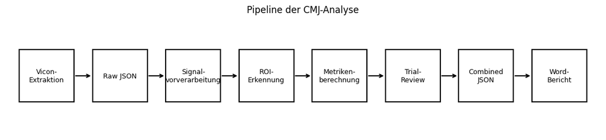

```python
# %%
fig, ax = plt.subplots(figsize=(14, 2.8))

steps = [
    "Vicon-\nExtraktion",
    "Raw JSON",
    "Signal-\nvorverarbeitung",
    "ROI-\nErkennung",
    "Metriken-\nberechnung",
    "Trial-\nReview",
    "Combined\nJSON",
    "Word-\nBericht",
]

x_positions = [0.3, 1.9, 3.5, 5.1, 6.7, 8.3, 9.9, 11.5]

for x, label in zip(x_positions, steps):
    ax.add_patch(plt.Rectangle((x, 1.0), 1.2, 0.8, fill=False, linewidth=1.5))
    ax.text(x + 0.6, 1.4, label, ha="center", va="center", fontsize=9)

for i in range(len(x_positions) - 1):
    ax.annotate(
        "",
        xy=(x_positions[i + 1], 1.4),
        xytext=(x_positions[i] + 1.2, 1.4),
        arrowprops=dict(arrowstyle="->", linewidth=1.5)
    )

ax.set_xlim(0, 13)
ax.set_ylim(0.5, 2.3)
ax.axis("off")
ax.set_title("Pipeline der CMJ-Analyse")
plt.show()
```

## 6. Biomechanische Grundlagen

Ein Countermovement Jump besteht aus mehreren funktionellen Bewegungsphasen:

1. Standphase
2. exzentrische Phase
3. Bremsphase
4. konzentrische Propulsionsphase
5. Flugphase
6. Landungsphase

Diese Phasen können anhand der vertikalen Bodenreaktionskraft und der Markertrajektorie identifiziert werden. Die Bewegung beruht auf dem **Stretch-Shortening-Cycle**, bei dem eine exzentrische Muskelaktion unmittelbar von einer konzentrischen Aktion gefolgt wird. Dabei wird mechanische Energie gespeichert und anschließend für die Beschleunigung des Körpers genutzt.

Die präzise ROI-Erkennung ist entscheidend, da viele biomechanische Kennwerte phasenspezifisch und nicht über das Gesamtsignal berechnet werden.

⬆ Zurück zum Inhaltsverzeichnis

## 7. Dynamische Gleichungen

Die Bewegung des Körperschwerpunktes basiert auf dem zweiten Newtonschen Gesetz:

$$ F = m \cdot a $$

wobei:

- $F$ die vertikale Bodenreaktionskraft,
- $m$ die Körpermasse,
- $a$ die vertikale Beschleunigung

bezeichnet.

Da die Kraftplatte die gesamte vertikale Bodenreaktionskraft misst, ergibt sich die Netto-Beschleunigung des Körperschwerpunktes zu:

$$ a(t) = \frac{F(t) - BW}{m} $$

wobei $BW$ das Körpergewicht in Newton ist.

Die Geschwindigkeit wird durch zeitliche Integration der Beschleunigung bestimmt:

$$ v(t) = \int a(t)\,dt $$

Die Position ergibt sich aus der Integration der Geschwindigkeit:

$$ s(t) = \int v(t)\,dt $$

Die Masse wird aus dem Körpergewicht bestimmt:

$$ m = \frac{BW}{g} $$

mit

$$ g = 9{,}81\ \text{m/s}^2 $$

Die Sprunghöhe kann grundsätzlich entweder aus der Absprungsgeschwindigkeit oder aus der Schwerpunkttrajektorie bestimmt werden:

$$ h = \frac{v_{\text{takeoff}}^2}{2g} $$

Im vorliegenden Framework wird die Sprunghöhe zusätzlich markerbasiert über die vertikale Schwerpunkt- bzw. Markertrajektorie bestimmt. Dadurch wird die rein kraftbasierte Berechnung um eine direkte kinematische Information ergänzt.

Die markerbasierte Trajektorie verbessert insbesondere die zeitliche Plausibilisierung der Bewegungsphasen sowie die Bestimmung des Bewegungsmaximums. In Kombination mit der Kraft-Zeit-Kurve erhöht dies die Robustheit der ROI-Erkennung und reduziert die Abhängigkeit von einer ausschließlich schwellenwertbasierten Ereignisdetektion.

⬆ Zurück zum Inhaltsverzeichnis

## 8. Beispieldatensatz

Für die Demonstration wird ein strukturiert abgelegter Beispieldatensatz verwendet. Die Ordnerstruktur entspricht der vorgesehenen Organisation des Frameworks mit Patient, Sitzung und Rohdatenordner.

Dadurch kann das Notebook dieselben Funktionen nutzen wie die eigentliche Anwendung. Die Dokumentation bleibt damit eng an die reale Implementierung gekoppelt und ist zugleich als technische Demonstration des Frameworks nutzbar.

⬆ Zurück zum Inhaltsverzeichnis

```python
# %%
# =========================================================
# Load one example trial
# =========================================================

trial_path = raw_files[0]

with open(trial_path, "r", encoding="utf-8") as f:
    trial_data = json.load(f)

print("Loaded trial:", trial_path.name)
trial_data.keys()
```

```
Loaded trial: 1234_10102020_01_data_cmj.json
```

```
dict_keys(['data_cache', 'user_info'])
```

## 9. Signalextraktion und Vorverarbeitung

Für die Demonstration wird ein einzelner Trial geladen und mit denselben Hilfsfunktionen verarbeitet, die auch im Framework verwendet werden.

Extrahiert werden:

- linke Kraft
- rechte Kraft
- Gesamtkraft
- vertikale Markertrajektorie

Anschließend erfolgen:

- Filterung der Kraftsignale
- Filterung der Markertrajektorie
- Umrechnung der Markertrajektorie in eine geeignete Längeneinheit
- Interpolation auf eine gemeinsame Signallänge

Die Markertrajektorie dient im Framework nicht nur der Visualisierung, sondern ist ein wesentlicher Bestandteil der Bewegungsphasen-Erkennung. Während die Kraftsignale vor allem Informationen über Kontakt, Belastung und Impuls liefern, erlaubt die Trajektorie eine präzisere Beschreibung der tatsächlichen vertikalen Bewegung.

Insbesondere die Kombination aus Kraftsignal und Markertrajektorie verbessert:

- die Erkennung des Bewegungsbeginns,
- die Identifikation des lokalen Minimums vor der konzentrischen Phase,
- die Bestimmung des Bewegungsmaximums,
- sowie die Abgrenzung einzelner ROI-Phasen.

Dadurch wird die Analyse robuster gegenüber rein kraftbasierten Fehlklassifikationen, insbesondere bei verrauschten Signalen oder uneindeutigen Schwellenwertübergängen.

Die Gesamtkraft ergibt sich aus:

$$ F_{\text{total}}(t) = F_L(t) + F_R(t) $$

wobei $F_L$ und $F_R$ die vertikalen Kräfte der linken bzw. rechten Kraftplatte darstellen.

⬆ Zurück zum Inhaltsverzeichnis

```python
# %%
# =========================================================
# Extract and preprocess signals
# =========================================================

valid_marker = trial_data["data_cache"]["valid_markers"]

force_left = np.array(trial_data["data_cache"]["forces"]["L"]["z"]["raw"], dtype=float)
force_right = np.array(trial_data["data_cache"]["forces"]["R"]["z"]["raw"], dtype=float)
trajectory_raw = np.array(trial_data["data_cache"]["markers"][valid_marker]["z"], dtype=float)

frame_rate = float(trial_data["user_info"]["framerate"])
plate_rate = float(trial_data["user_info"]["platerate"])

f_force_left = SignalProcessing.filter(force_left)
f_force_right = SignalProcessing.filter(force_right)
f_force_total = SignalProcessing.filter(force_left + force_right)

trajectory_cm = SignalProcessing.butter_lowpass(
    SignalProcessing.convert_distance(trajectory_raw),
    frame_rate
)

interp_trajectory = SignalProcessing.interpolate(
    len(trajectory_cm),
    len(f_force_total),
    trajectory_cm
)

time = np.arange(len(f_force_total), dtype=float) / plate_rate
duration = max(time)

print("Anzahl Kraftwerte:", len(f_force_total))
print("Anzahl Trajektorienwerte:", len(trajectory_cm))
print("Interpolierte Trajektorie:", len(interp_trajectory))
print("frame_rate:", frame_rate)
print("plate_rate:", plate_rate)
print("Dauer der Trial-Aufnahme:", duration)
```

```
Anzahl Kraftwerte: 6640
Anzahl Trajektorienwerte: 1328
Interpolierte Trajektorie: 6640
frame_rate: 200.0
plate_rate: 1000.0
Dauer der Trial-Aufnahme: 6.639
```

```python
# Comparison with TempProcessedData

trial_name = os.path.splitext(os.path.basename(trial_path.name))[0]
TempProcessedData.remove_trial(trial_name)
trial_content = TempProcessedData.load(str(trial_path), trial_name)

print(trial_content.__dict__.keys())
print("frame_rate:", trial_content.frame_rate)
print("plate_rate:", getattr(trial_content, "plate_rate", None))
```

```
dict_keys(['_initialized', 'trial_name', 'Fz_l', 'Fz_r', 'F_total', 'trajectory', 'frame_rate', 'plate_rate', 'json_path', 'validation_result'])
frame_rate: 200.0
plate_rate: 1000.0
```

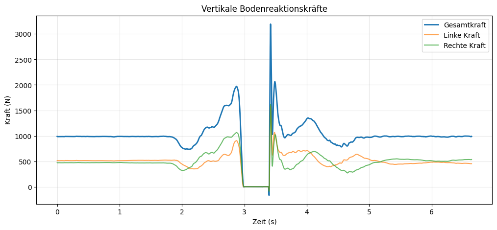

```python
fig, ax = plt.subplots(figsize=(12, 5))
ax.plot(time, f_force_total, label="Gesamtkraft", linewidth=2)
ax.plot(time, f_force_left, label="Linke Kraft", alpha=0.7)
ax.plot(time, f_force_right, label="Rechte Kraft", alpha=0.7)

ax.set_title("Vertikale Bodenreaktionskräfte")
ax.set_xlabel("Zeit (s)")
ax.set_ylabel("Kraft (N)")
ax.legend()
ax.grid(True, alpha=0.3)
plt.show()
```

## 10. ROI-Erkennung

Die Bewegungsphasen des Sprungs werden als **Regions of Interest (ROI)** definiert.

Die automatische Erkennung basiert auf einer kombinierten Auswertung von:

- vertikalem Kraftverlauf,
- markerbasierter Vertikaltrajektorie,
- lokalen Extrema,
- schwellenwertbasierten Kontaktkriterien,
- sowie zeitlichen Beziehungen zwischen den Ereignissen.

Die Markertrajektorie stellt dabei einen wichtigen Zusatz zur Kraftanalyse dar. Sie erlaubt insbesondere eine robustere Identifikation biomechanisch plausibler Bewegungsabschnitte, da der zeitliche Verlauf der tatsächlichen Auf- und Abwärtsbewegung des Körpers in die ROI-Erkennung einbezogen wird.

Im aktuellen Framework wird die ROI-Erkennung daher nicht ausschließlich über Kraftschwellen bestimmt, sondern durch trajektorienbasierte Strukturmerkmale ergänzt. Dies verbessert die Konsistenz der Phasenaufteilung, vor allem im Bereich von Bewegungsbeginn, Umkehrpunkt und Landungsverlauf. Zu den zentralen Ereignissen zählen unter anderem:

- **stand**: stabile Standphase
- **start**: Beginn der relevanten Bewegung
- **takeoff**: Absprung
- **landing**: Landung

Die ROI-Erkennung ist entscheidend, da zahlreiche biomechanische Parameter nicht über das gesamte Signal, sondern phasenspezifisch berechnet werden.

Absprung und Landung werden primär über das Kraftsignal beziehungsweise den Kontaktverlust zur Kraftplatte erkannt. Die innere Struktur der Bewegung, insbesondere Bewegungsbeginn, lokales Minimum und postlandungsbezogene Phasenabgrenzung, wird jedoch durch die markerbasierte Trajektorie zusätzlich stabilisiert.

⬆ Zurück zum Inhaltsverzeichnis

```python
# %%
# =========================================================
# Detect CMJ phases
# =========================================================

roi = CMJ_ROI(f_force_total, interp_trajectory, trial_data["user_info"]["platerate"])
print(roi.as_dict())

#or through TempProcessedData
#roi_temp = CMJ_ROI(trial_content.F_total,trial_content.trajectory, trial_content.plate_rate)
#print(roi_temp.as_dict())
```

```
{'Jump_height': 25.03, 'bodyweight': 986.68, 'mass': 100.58, 'eccentric': {'unloading': (2079, 2114), 'braking': (2114, 2621), 'deceleration': (2288, 2621)}, 'concentric': {'propulsion_p1': (2621, 2802), 'propulsion_p2': (2802, 2983)}, 'takeoff': (2802, 2983), 'landing': (3397, 3971)}
```

### 11. Wissenschaftliche Force-Time-Darstellung

Die folgende Abbildung zeigt eine vertikale Kraft-Zeit-Kurve mit annotierten biomechanischen Ereignissen und ROI-Phasen.

Die grafische Darstellung erlaubt die visuelle Kontrolle von:

- Signalqualität
- Phasenabgrenzung
- Kraftentwicklung
- Absprung- und Landungsereignissen

Gerade im klinischen Kontext ist diese Darstellung wichtig, um fehlerhafte Trials frühzeitig zu erkennen und die automatische Analyse zu plausibilisieren.

Im Framework wird hierfür zusätzlich die Klasse `CMJPlot` verwendet, die dieselbe Logik wie die GUI-Darstellung nutzt.

⬆ Zurück zum Inhaltsverzeichnis

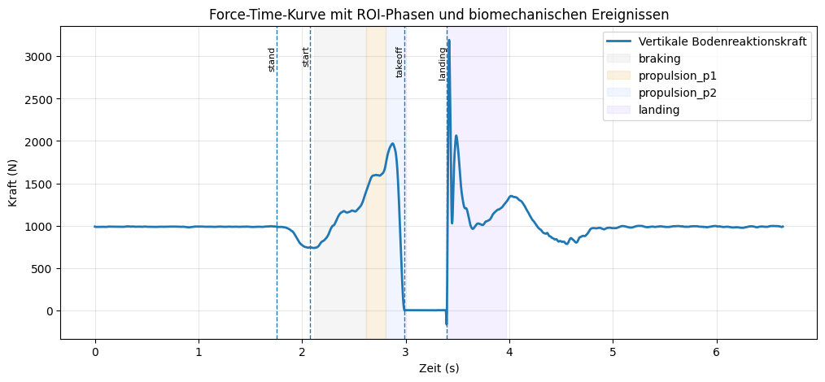

```python
# %%
fig, ax = plt.subplots(figsize=(12, 5))

ax.plot(time, f_force_total, label="Vertikale Bodenreaktionskraft", linewidth=2)

ecc = roi.eccentric_phases if hasattr(roi, "eccentric_phases") else {}
conc = roi.concentric_phases if hasattr(roi, "concentric_phases") else {}

phase_colors = {
    "braking": "#d9d9d9",
    "propulsion_p1": "#f0c987",
    "propulsion_p2": "#c7dbff",
    "landing": "#d9c7ff",
}

phase_spans = {
    "braking": ecc.get("braking") if isinstance(ecc, dict) else None,
    "propulsion_p1": conc.get("propulsion_p1") if isinstance(conc, dict) else None,
    "propulsion_p2": conc.get("propulsion_p2") if isinstance(conc, dict) else None,
    "landing": getattr(roi, "landing_phase", None),
}

for name, span in phase_spans.items():
    if span and len(span) == 2:
        s, e = span
        ax.axvspan(time[int(s)], time[int(e)], alpha=0.25, label=name, color=phase_colors[name])

event_candidates = {
    "stand": getattr(roi, "stand", None),
    "start": getattr(roi, "start", None),
    "takeoff": getattr(roi, "takeoff_idx", None),
    "landing": getattr(roi, "landing_idx", None),
}

ymax = np.max(f_force_total)

for label, idx in event_candidates.items():
    if idx is not None:
        idx = int(idx)
        ax.axvline(time[idx], linestyle="--", linewidth=1)
        ax.text(time[idx], ymax * 0.98, label, rotation=90, va="top", ha="right", fontsize=8)

ax.set_title("Force-Time-Kurve mit ROI-Phasen und biomechanischen Ereignissen")
ax.set_xlabel("Zeit (s)")
ax.set_ylabel("Kraft (N)")
ax.legend(loc="upper right")
ax.grid(True, alpha=0.3)
plt.show()
```

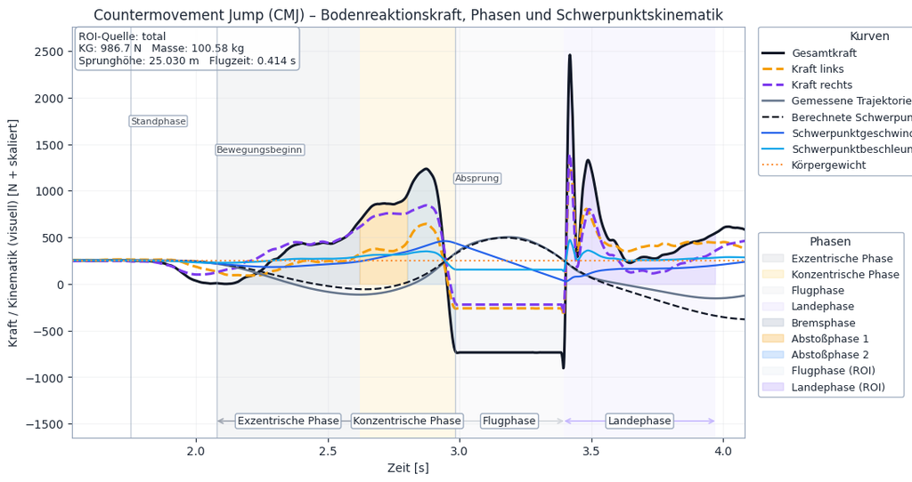

```python
# =========================================================
# Plot with CMJPlot
# =========================================================

plotter = CMJPlot(
    f_force_left,
    f_force_right,
    f_force_total,
    interp_trajectory,
    trial_data["user_info"]["platerate"]
)

fig, ax = plt.subplots(figsize=(12, 6))
plotter.plot_embedded(ax)
plt.show()
```

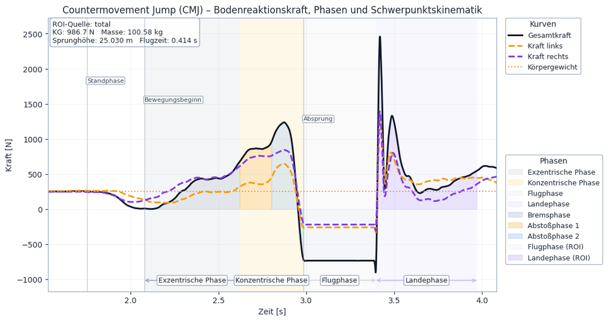

```python
fig, ax = plt.subplots(figsize=(12, 6))
plotter.plot_embedded(ax)
plotter.set_view("force", redraw=False)
plotter.set_roi_source("total")
plotter.set_zoom_mode("roi")
plt.show()
```

## 12. Berechnung der Metriken

Das Framework berechnet verschiedene biomechanische Kennwerte:

- Sprunghöhe
- Peak Force
- Rate of Force Development
- Concentric Power
- Impuls
- Phasendauer
- Loading Rate
- Peak Landing Force
- Links-Rechts-Asymmetrien

### Sprunghöhe

Die Sprunghöhe kann aus der Absprunggeschwindigkeit oder aus der Schwerpunktverschiebung bestimmt werden:

$$ h = \frac{v_{\text{takeoff}}^2}{2g} $$

### Impuls

Der Impuls entspricht dem Integral der Kraft über die Zeit:

$$ J = \int F(t)\,dt $$

Für den Nettoimpuls relativ zum Körpergewicht gilt:

$$ J_{\text{net}} = \int \bigl(F(t) - BW\bigr)\,dt $$

### Absprungsgeschwindigkeit

Die Absprunggeschwindigkeit ergibt sich aus dem Impuls-Masse-Zusammenhang:

$$ v_{\text{takeoff}} = \frac{J_{\text{net}}}{m} $$

### Leistung

Die mechanische Leistung wird aus Kraft und Geschwindigkeit berechnet:

$$ P(t) = F(t) \cdot v(t) $$

Daraus lassen sich mittlere und maximale Leistung bestimmen.

Im Framework wird die Leistung phasenspezifisch aus Kraft und der vertikalen Geschwindigkeit des Gesamtschwerpunktes berechnet. Für die links-rechts-seitige Leistungsanalyse werden die linken und rechten Kraftanteile mit derselben vertikalen COM-Geschwindigkeit kombiniert. Damit beschreibt die resultierende Kenngröße keine segmentale Gelenkleistung im engeren Sinn, sondern eine funktionelle links-rechts-seitige Beitragsanalyse zur Gesamtbewegung.

### Rate of Force Development

Die Rate of Force Development beschreibt die zeitliche Änderung der Kraft:

$$ RFD(t) = \frac{dF(t)}{dt} $$

Zusätzlich können zeitfensterbasierte RFD-Werte berechnet werden, zum Beispiel über 100 ms oder 200 ms.

### RSI modified

Der modifizierte Reactive Strength Index ergibt sich aus Sprunghöhe und Zeit bis zum Absprung:

$$ RSI_{\text{mod}} = \frac{h}{t_{\text{takeoff}}} $$

### Phasendauern

Die Dauer einer Phase ergibt sich allgemein aus:

$$ \Delta t = \frac{n_{\text{Ende}} - n_{\text{Start}}}{f_s} $$

wobei $f_s$ die Abtastrate ist.

### Links-Rechts-Asymmetrie

Die Links-Rechts-Asymmetrie wird im aktuellen Framework als standardisierter Asymmetrieindex auf Basis der linken und rechten Teilgröße berechnet:

$$ ASI = \frac{|\,|L| - |R|\,|}{\left(\frac{|L| + |R|}{2}\right)} \cdot 100 $$

wobei $L$ und $R$ die links- bzw. rechtsseitigen Werte der betrachteten Metrik darstellen, zum Beispiel Impuls oder mittlere Leistung innerhalb einer definierten Phase.

Diese Formulierung ist gegenüber einer Normierung über den Totalwert methodisch vorteilhaft, da die Asymmetrie direkt auf der bilateralen Mittelgröße basiert. Dadurch wird die Links-Rechts-Differenz konsistenter und phasenspezifisch besser interpretierbar.

Zusätzlich werden im Framework die prozentualen Beiträge beider Seiten relativ zum Totalwert berechnet:

$$ Beitrag_L = \frac{|L|}{|T|} \cdot 100 \qquad\text{und}\qquad Beitrag_R = \frac{|R|}{|T|} \cdot 100 $$

Damit werden Asymmetrie und Seitenbeitrag getrennt beschrieben: Der Asymmetrieindex quantifiziert die bilaterale Differenz, während die Beitragswerte den Anteil der linken bzw. rechten Seite am Gesamtwert angeben.

⬆ Zurück zum Inhaltsverzeichnis

```python
# =========================================================
# Compute jump metrics
# =========================================================

metrics = JumpMetrics(
    f_force_left,
    f_force_right,
    f_force_total,
    interp_trajectory,
    plate_rate
)

results = metrics.all_metrics
results
```

```
{'jump_height': 25.03,
 'weight': 986.683145966203,
 'PeakForce': {'braking': 1411.93,
  'deceleration': 1411.93,
  'propulsion': 1970.94,
  'landing': 3193.64},
 'RFD': {'RFD_max': 4099.91, 'RFD_0_100ms': 2399.37, 'RFD_0_200ms': 1864.44},
 'RSI_modified': 27.688,
 'Takeoff_velocity': 1.87,
 'ConcentricPower': {'Power_mean': 1503.51, 'Power_peak': 3485.76},
 'LandingMetrics': {'LoadingRate_peak': 207945.4, 'PeakLandingForce': 3193.6},
 'PhaseDurations': {'Eccentric_duration': 0.542,
  'Concentric_duration': 0.362,
  'Time_to_takeoff': 0.904},
 'Asymmetry': {'Impulse': {'Takeoff': {'L': 120.89,
    'R': 148.84,
    'delta_percent': 20.73,
    'contribution_L_percent': 44.82,
    'contribution_R_percent': 55.18},
   'Braking': {'L': 226.23,
    'R': 307.03,
    'delta_percent': 30.3,
    'contribution_L_percent': 42.42,
    'contribution_R_percent': 57.58},
   'Deceleration': {'L': 163.69,
    'R': 225.78,
    'delta_percent': 31.89,
    'contribution_L_percent': 42.03,
    'contribution_R_percent': 57.97},
   'Propulsion': {'L': 234.71,
    'R': 320.37,
    'delta_percent': 30.87,
    'contribution_L_percent': 42.28,
    'contribution_R_percent': 57.72},
   'Landing': {'L': 423.68,
    'R': 310.74,
    'delta_percent': 30.76,
    'contribution_L_percent': 57.69,
    'contribution_R_percent': 42.31}},
  'Power': {'Takeoff': {'L': 1052.95,
```

[output cut: 9 more lines]

```
   'Deceleration': {'L': -230.29,
    'R': -316.72,
    'delta_percent': 31.6,
    'contribution_L_percent': 42.1,
    'contribution_R_percent': 57.9},
   'Propulsion': {'L': 656.61,
    'R': 846.9,
    'delta_percent': 25.31,
    'contribution_L_percent': 43.67,
    'contribution_R_percent': 56.33},
   'Landing': {'L': -795.7,
    'R': -617.05,
    'delta_percent': 25.29,
    'contribution_L_percent': 56.32,
    'contribution_R_percent': 43.68}}}}
```

```python
pd.DataFrame([results])
```

|  | jump_height | weight | PeakForce | RFD | RSI_modified | Takeoff_velocity | ConcentricPower | LandingMetrics | PhaseDurations | Asymmetry |
| --- | --- | --- | --- | --- | --- | --- | --- | --- | --- | --- |
| 0 | 25.03 | 986.683146 | {'braking': 1411.93, 'deceleration': 1411.93, ... | {'RFD_max': 4099.91, 'RFD_0_100ms': 2399.37, '... | 27.688 | 1.87 | {'Power_mean': 1503.51, 'Power_peak': 3485.76} | {'LoadingRate_peak': 207945.4, 'PeakLandingFor... | {'Eccentric_duration': 0.542, 'Concentric_dura... | {'Impulse': {'Takeoff': {'L': 120.89, 'R': 148... |

## 13. Analyse mehrerer Trials

Zur Beurteilung der intraindividuellen Reproduzierbarkeit können mehrere Sprungversuche desselben Patienten ausgewertet und miteinander verglichen werden.

Dadurch lassen sich unter anderem beurteilen:

- Konsistenz der Sprunghöhe
- Stabilität der Kraftentwicklung
- Schwankungen der Asymmetrien
- mögliche Ermüdungseffekte oder Ausreißer

Die Analyse mehrerer Trials ist insbesondere im klinischen Alltag sinnvoll, da einzelne Sprünge durch technische oder motorische Besonderheiten verfälscht sein können.

⬆ Zurück zum Inhaltsverzeichnis

```python
all_results = []

for file in raw_files:
    trial_name = os.path.splitext(os.path.basename(file.name))[0]
    TempProcessedData.remove_trial(trial_name)
    temp = TempProcessedData.load(str(file), trial_name)

    metrics = JumpMetrics(
        temp.Fz_l,
        temp.Fz_r,
        temp.F_total,
        temp.trajectory,
        temp.frame_rate
    )

    result = metrics.all_metrics
    result["trial"] = trial_name
    all_results.append(result)

df_results = pd.DataFrame(all_results)
df_results
```

|  | jump_height | weight | PeakForce | RFD | RSI_modified | Takeoff_velocity | ConcentricPower | LandingMetrics | PhaseDurations | Asymmetry | trial |
| --- | --- | --- | --- | --- | --- | --- | --- | --- | --- | --- | --- |
| 0 | 25.03 | 985.093681 | {'braking': 1411.93, 'deceleration': 1411.93, ... | {'RFD_max': 819.98, 'RFD_0_100ms': 769.54, 'RF... | 5.538 | 9.45 | {'Power_mean': 7855.92, 'Power_peak': 17867.0} | {'LoadingRate_peak': 41589.1, 'PeakLandingForc... | {'Eccentric_duration': 2.71, 'Concentric_durat... | {'Impulse': {'Takeoff': {'L': 604.43, 'R': 744... | 1234_10102020_01_data_cmj |
| 1 | 23.68 | 985.895234 | {'braking': 1630.88, 'deceleration': 1630.88, ... | {'RFD_max': 1052.02, 'RFD_0_100ms': 993.01, 'R... | 6.366 | 9.03 | {'Power_mean': 8670.56, 'Power_peak': 18229.53} | {'LoadingRate_peak': 7551.4, 'PeakLandingForce... | {'Eccentric_duration': 2.22, 'Concentric_durat... | {'Impulse': {'Takeoff': {'L': 529.43, 'R': 506... | 1234_10102020_02_data_cmj |
| 2 | 25.60 | 986.723059 | {'braking': 1688.85, 'deceleration': 1688.85, ... | {'RFD_max': 1345.8, 'RFD_0_100ms': 1282.52, 'R... | 4.981 | 9.44 | {'Power_mean': 8614.8, 'Power_peak': 17349.81} | {'LoadingRate_peak': 17598.9, 'PeakLandingForc... | {'Eccentric_duration': 3.42, 'Concentric_durat... | {'Impulse': {'Takeoff': {'L': 570.45, 'R': 596... | 1234_10102020_03_data_cmj |
| 3 | 27.63 | 986.508908 | {'braking': 1814.37, 'deceleration': 1814.37, ... | {'RFD_max': 1822.04, 'RFD_0_100ms': 1710.24, '... | 6.433 | 9.85 | {'Power_mean': 9625.1, 'Power_peak': 19009.08} | {'LoadingRate_peak': 18933.6, 'PeakLandingForc... | {'Eccentric_duration': 2.75, 'Concentric_durat... | {'Impulse': {'Takeoff': {'L': 469.76, 'R': 597... | 1234_10102020_04_data_cmj |
| 4 | 26.61 | 986.044349 | {'braking': 1629.19, 'deceleration': 1629.19, ... | {'RFD_max': 1164.49, 'RFD_0_100ms': 1080.29, '... | 5.073 | 9.50 | {'Power_mean': 8244.56, 'Power_peak': 17868.95} | {'LoadingRate_peak': 7917.1, 'PeakLandingForce... | {'Eccentric_duration': 3.46, 'Concentric_durat... | {'Impulse': {'Takeoff': {'L': 611.97, 'R': 656... | 1234_10102020_05_data_cmj |
| 5 | 28.13 | 986.806134 | {'braking': 1759.56, 'deceleration': 1759.56, ... | {'RFD_max': 1462.65, 'RFD_0_100ms': 1429.63, '... | 5.078 | 9.84 | {'Power_mean': 9171.26, 'Power_peak': 19186.07} | {'LoadingRate_peak': 10963.7, 'PeakLandingForc... | {'Eccentric_duration': 3.845, 'Concentric_dura... | {'Impulse': {'Takeoff': {'L': 617.78, 'R': 558... | 1234_10102020_06_data_cmj |
| 6 | 26.93 | 987.444067 | {'braking': 1640.21, 'deceleration': 1640.21, ... | {'RFD_max': 981.44, 'RFD_0_100ms': 943.46, 'RF... | 4.647 | 9.75 | {'Power_mean': 8664.9, 'Power_peak': 18339.98} | {'LoadingRate_peak': 7724.0, 'PeakLandingForce... | {'Eccentric_duration': 3.99, 'Concentric_durat... | {'Impulse': {'Takeoff': {'L': 583.45, 'R': 681... | 1234_10102020_07_data_cmj |
| 7 | 25.40 | 987.989064 | {'braking': 1780.46, 'deceleration': 1780.46, ... | {'RFD_max': 1414.66, 'RFD_0_100ms': 1350.35, '... | 4.743 | 9.49 | {'Power_mean': 8569.72, 'Power_peak': 17626.97} | {'LoadingRate_peak': 7752.5, 'PeakLandingForce... | {'Eccentric_duration': 3.765, 'Concentric_dura... | {'Impulse': {'Takeoff': {'L': 497.42, 'R': 594... | 1234_10102020_08_data_cmj |
| 8 | 27.63 | 987.813228 | {'braking': 1870.69, 'deceleration': 1870.69, ... | {'RFD_max': 1493.31, 'RFD_0_100ms': 1441.75, '... | 5.548 | 10.23 | {'Power_mean': 9819.01, 'Power_peak': 20353.69} | {'LoadingRate_peak': 18508.2, 'PeakLandingForc... | {'Eccentric_duration': 3.455, 'Concentric_dura... | {'Impulse': {'Takeoff': {'L': 516.49, 'R': 598... | 1234_10102020_09_data_cmj |

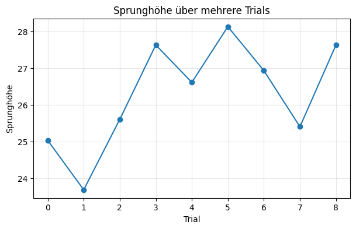

```python
plt.figure(figsize=(7, 4))
plt.plot(df_results["jump_height"], marker="o")
plt.title("Sprunghöhe über mehrere Trials")
plt.xlabel("Trial")
plt.ylabel("Sprunghöhe")
plt.grid(True, alpha=0.3)
plt.show()
```

## 14. Schematische CMJ-Darstellung

Die schematische Darstellung dient der konzeptionellen Einordnung der Bewegungsphasen eines Countermovement Jumps.

Sie hilft dabei, die im Signal erkannten ROI-Phasen mit dem tatsächlichen motorischen Ablauf zu verknüpfen:

- Stand
- Abwärtsbewegung
- Bremsphase
- Propulsion
- Flugphase
- Landung

⬆ Zurück zum Inhaltsverzeichnis

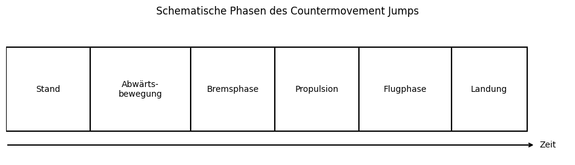

```python
# %%
fig, ax = plt.subplots(figsize=(12, 3))

phases = [
    ("Stand", 0, 1),
    ("Abwärts-\nbewegung", 1, 2.2),
    ("Bremsphase", 2.2, 3.2),
    ("Propulsion", 3.2, 4.2),
    ("Flugphase", 4.2, 5.3),
    ("Landung", 5.3, 6.2),
]

for label, x0, x1 in phases:
    ax.add_patch(plt.Rectangle((x0, 0.2), x1 - x0, 0.6, fill=False, linewidth=1.5))
    ax.text((x0 + x1) / 2, 0.5, label, ha="center", va="center", fontsize=10)

ax.annotate("", xy=(6.3, 0.1), xytext=(0, 0.1),
            arrowprops=dict(arrowstyle="->", linewidth=1.5))
ax.text(6.35, 0.1, "Zeit", va="center")

ax.set_xlim(0, 6.7)
ax.set_ylim(0, 1)
ax.axis("off")
ax.set_title("Schematische Phasen des Countermovement Jumps")
plt.show()
```

## 15. Architekturdiagramm des Frameworks

Das Architekturdiagramm zeigt die funktionellen Beziehungen zwischen Rohdaten, Analysemodulen, Visualisierung, Konfiguration und Export.

Es verdeutlicht, wie die einzelnen Pakete des Frameworks zusammenarbeiten und welche Rolle jedes Modul innerhalb des Gesamtprozesses übernimmt.

⬆ Zurück zum Inhaltsverzeichnis

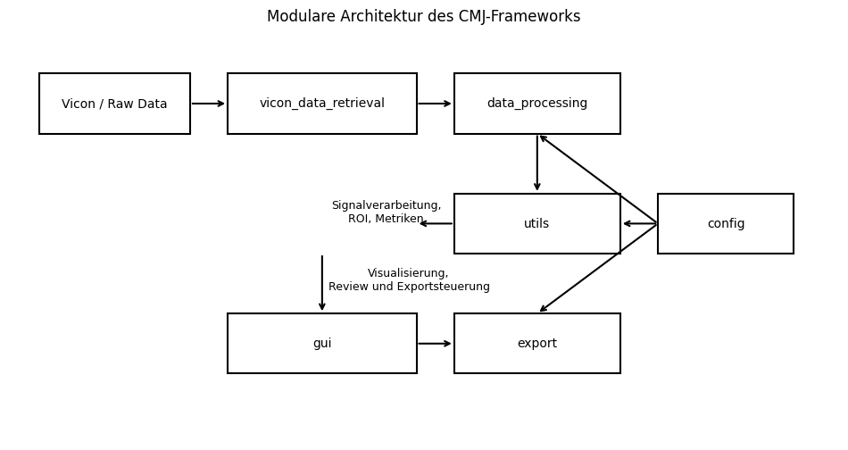

```python
# %%
fig, ax = plt.subplots(figsize=(12, 6))

boxes = {
    "Vicon / Raw Data": (0.4, 4.3, 2.0, 0.8),
    "vicon_data_retrieval": (2.9, 4.3, 2.5, 0.8),
    "data_processing": (5.9, 4.3, 2.2, 0.8),
    "utils": (5.9, 2.7, 2.2, 0.8),
    "gui": (2.9, 1.1, 2.5, 0.8),
    "export": (5.9, 1.1, 2.2, 0.8),
    "config": (8.6, 2.7, 1.8, 0.8),
}

for label, (x, y, w, h) in boxes.items():
    ax.add_patch(plt.Rectangle((x, y), w, h, fill=False, linewidth=1.5))
    ax.text(x + w / 2, y + h / 2, label, ha="center", va="center", fontsize=10)

arrows = [
    ((2.4, 4.7), (2.9, 4.7)),
    ((5.4, 4.7), (5.9, 4.7)),
    ((7.0, 4.3), (7.0, 3.5)),
    ((5.9, 3.1), (5.4, 3.1)),
    ((4.15, 2.7), (4.15, 1.9)),
    ((5.4, 1.5), (5.9, 1.5)),
    ((8.6, 3.1), (8.1, 3.1)),
    ((8.6, 3.1), (7.0, 4.3)),
    ((8.6, 3.1), (7.0, 1.9)),
]

for start, end in arrows:
    ax.annotate("", xy=end, xytext=start, arrowprops=dict(arrowstyle="->", linewidth=1.5))

ax.text(5.0, 3.25, "Signalverarbeitung,\nROI, Metriken", ha="center", va="center", fontsize=9)
ax.text(5.3, 2.35, "Visualisierung,\nReview und Exportsteuerung", ha="center", va="center", fontsize=9)

ax.set_xlim(0, 11)
ax.set_ylim(0.2, 5.7)
ax.axis("off")
ax.set_title("Modulare Architektur des CMJ-Frameworks")
plt.show()
```

## 16. Grafische Benutzeroberfläche

Die grafische Benutzeroberfläche des aktuellen CMJ-Frameworks dient als zentrale Arbeitsoberfläche für klinische und technische Nutzer. Sie integriert Analyse, Dateiverwaltung, Trial-Visualisierung, Parameterverwaltung und Export in einer zusammenhängenden Anwendung.

### 16.1 Hauptfenster / Welcome Window

[figure not shown]

Das Hauptfenster bildet den Einstiegspunkt der Anwendung. Von hier aus kann zwischen Analyse, Export, Parameteransicht und Dokumentation navigiert werden.

### 16.2 Analyse- und Visualisierungsbereich

[figure not shown]

Dieser Bereich ermöglicht die grafische Darstellung der Kraft- und Kinematiksignale, ROI-basierte Ansichten der Bewegungsphasen sowie die manuelle Beurteilung einzelner Trials.

### 16.3 Folder Explorer

[figure not shown]

Der Folder Explorer erlaubt die Navigation innerhalb der CMJ-Ordnerstruktur, das Öffnen von JSON-Dateien sowie die Vorschau extrahierter oder verarbeiteter Daten.

### 16.4 Export-Ansicht

[figure not shown]

In der Exportansicht wird eine kombinierte JSON-Datei ausgewählt und daraus ein standardisierter Word-Bericht erzeugt. Zusätzlich können exportierte Parameter und markdown-basierte Berichtsinhalte angepasst werden.

### 16.5 Parameter-Ansicht

[figure not shown]

Die Parameteransicht ermöglicht die Anzeige, Bearbeitung, Validierung und das Zurücksetzen zentraler JSON-Konfigurationen des Frameworks. Damit ist die Konfigurationsverwaltung ein integraler Bestandteil der GUI geworden.

⬆ Zurück zum Inhaltsverzeichnis

## 17. Berichtserstellung

Nach Abschluss der Analyse kann aus einer kombinierten Ergebnisdatei (`*_combined.json`) automatisch ein standardisierter Word-Bericht erzeugt werden.

Der Bericht enthält unter anderem:

- Leistungsparameter mehrerer Trials
- Tabellen zur Links-Rechts-Asymmetrie
- patientenspezifische Metadaten
- markdown-basierte Beschreibungen von Parametern und Bewegungsphasen

Das aktuelle Framework erlaubt zusätzlich:

- die Auswahl aktivierter Exportparameter
- das Nachladen und Speichern editierbarer Markdown-Inhalte
- die automatische Ablage des Berichts im patienten- und sitzungsbezogenen `reports`-Ordner

Damit ist die Berichtserstellung nicht mehr nur ein starrer Endschritt, sondern ein konfigurierbarer Bestandteil des Analyse-Workflows.

⬆ Zurück zum Inhaltsverzeichnis

## 18. Methodische Hinweise

Die in diesem Notebook dargestellten Berechnungen verwenden die tatsächlichen Funktionen des aktuellen CMJ-Frameworks. Dadurch entspricht die Dokumentation direkt der implementierten Analyselogik.

Verwendet werden insbesondere:

- `SignalProcessing`
- `CMJ_ROI`
- `JumpMetrics`
- `CMJPlot`
- `TempProcessedData`
- `PathManager`

Das Notebook dient daher nicht nur der Dokumentation, sondern auch als reproduzierbare technische Demonstration des Analyseprozesses.

Bei der Interpretation ist zu beachten:

- Kraft- und Markertrajektorien können unterschiedliche Abtastraten besitzen
- Interpolation wird verwendet, um eine gemeinsame Signalbasis herzustellen
- die ROI-Erkennung beeinflusst direkt zahlreiche abgeleitete Metriken
- Konfigurationsdateien bestimmen wesentliche Schwellenwerte und Filterparameter
- die GUI ergänzt die automatische Verarbeitung um eine visuelle Qualitätskontrolle

⬆ Zurück zum Inhaltsverzeichnis

## 19. Literatur

## Literatur

- Aagaard P, Simonsen EB, Andersen JL, Magnusson P, Dyhre-Poulsen P. Increased rate of force development and neural drive of human skeletal muscle following resistance training. *Journal of Applied Physiology*. 2002.
- Maffiuletti NA, Aagaard P, Blazevich AJ, Folland J, Tillin N, Duchateau J. Rate of force development: physiological and methodological considerations. *European Journal of Applied Physiology*. 2016.
- McMahon JJ, Suchomel TJ, Lake JP, Comfort P. Understanding the key phases of the countermovement jump force-time curve. *Strength and Conditioning Journal*. 2018.
- McMahon JJ, Comfort P. Influence of countermovement depth on reactive strength index modified. *International Journal of Sports Physiology and Performance*. 2018.
- Cormie P, McGuigan MR, Newton RU. Developing maximal neuromuscular power: Part 1 – Biological basis of maximal power production. *Sports Medicine*. 2011.
- Cormie P, McGuigan MR, Newton RU. Developing maximal neuromuscular power: Part 2 – Training considerations for improving maximal power production. *Sports Medicine*. 2011.
- Lake JP, Mundy PD, Comfort P. Power and impulse applied during push-off correlate with jump performance in the countermovement jump. *Journal of Strength and Conditioning Research*. 2014.
- Suchomel TJ, Nimphius S, Stone MH. The importance of muscular strength in athletic performance. *Sports Medicine*. 2016.
- Bishop C, Turner A, Read P. Effects of inter-limb asymmetries on physical and sports performance: a systematic review. *Sports Medicine*. 2018.
- Maloney SJ. The relationship between asymmetry and athletic performance. *Journal of Strength and Conditioning Research*. 2019.

⬆ Zurück zum Inhaltsverzeichnis